# Causal Inference

Topics II

Macartan Humphreys

## 1 Noncompliance and the LATE estimand

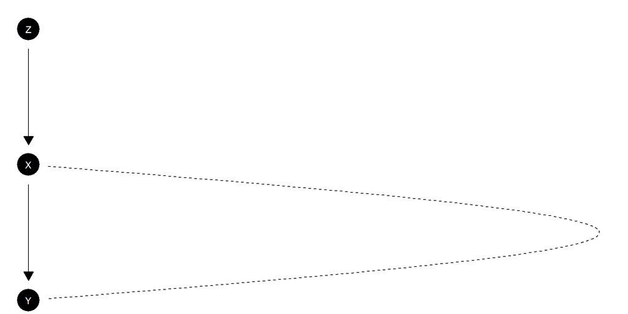

### 1.1 Local Average Treatment Effects

Sometimes you give a medicine but only a nonrandom sample of people actually try to use it. Can you still estimate the medicine’s effect?

|  | X=0 | X=1 |
| --- | --- | --- |
| Z=0 | $\overline{y}_{00}$ ($n_{00}$) | $\overline{y}_{01}$ ($n_{01}$) |
| Z=1 | $\overline{y}_{10}$ ($n_{10}$) | $\overline{y}_{11}$ ($n_{11}$) |

Say that people are one of 3 types:

1. $n_a$ “always takers” have $X=1$ no matter what and have average outcome $\overline{y}_a$
2. $n_n$ “never takers” have $X=0$ no matter what with outcome $\overline{y}_n$
3. $n_c$ “compliers have” $X=Z$ and average outcomes $\overline{y}^1_c$ if treated and $\overline{y}^0_c$ if not.

### 1.2 Local Average Treatment Effects

Sometimes you give a medicine but only a nonrandom sample of people actually try to use it. Can you still estimate the medicine’s effect?

|  | X=0 | X=1 |
| --- | --- | --- |
| Z=0 | $\overline{y}_{00}$ ($n_{00}$) | $\overline{y}_{01}$ ($n_{01}$) |
| Z=1 | $\overline{y}_{10}$ ($n_{10}$) | $\overline{y}_{11}$ ($n_{11}$) |

We can figure something about types:

|  | $X=0$ | $X=1$ |
| --- | --- | --- |
| $Z=0$ | $\frac{\frac{1}{2}n_c}{\frac{1}{2}n_c + \frac{1}{2}n_n} \overline{y}^0_{c}+\frac{\frac{1}{2}n_n}{\frac{1}{2}n_c + \frac{1}{2}n_n} \overline{y}_{n}$ | $\overline{y}_{a}$ |
| $Z=1$ | $\overline{y}_{n}$ | $\frac{\frac{1}{2}n_c}{\frac{1}{2}n_c + \frac{1}{2}n_a} \overline{y}^1_{c}+\frac{\frac{1}{2}n_a}{\frac{1}{2}n_c + \frac{1}{2}n_a} \overline{y}_{a}$ |

### 1.3 Local Average Treatment Effects

You give a medicine to 50% but only a non random sample of people actually try to use it. Can you still estimate the medicine’s effect?

|  | $X=0$ | $X=1$ |
| --- | --- | --- |
| $Z=0$ | $\frac{n_c}{n_c + n_n} \overline{y}^0_{c}+\frac{n_n}{n_c + n_n} \overline{y}_n$ | $\overline{y}_{a}$ |
| (n) | ($\frac{1}{2}(n_c + n_n)$) | ($\frac{1}{2}n_a$) |
| $Z=1$ | $\overline{y}_{n}$ | $\frac{n_c}{n_c + n_a} \overline{y}^1_{c}+\frac{n_a}{n_c + n_a} \overline{y}_{a}$ |
| (n) | ($\frac{1}{2}n_n$) | ($\frac{1}{2}(n_a+n_c)$) |

Key insight: the contributions of the $a$s and $n$s are the *same* in the $Z=0$ and $Z=1$ groups so if you difference you are left with the *changes* in the contributions of the $c$s.

### 1.4 Local Average Treatment Effects

Average in $Z=0$ group: $\frac{{n_c} \overline{y}^0_{c}+ \left(n_{n}\overline{y}_{n} +{n_a} \overline{y}_a\right)}{n_a+n_c+n_n}$

Average in $Z=1$ group: $\frac{{n_c} \overline{y}^1_{c} + \left(n_{n}\overline{y}_{n} +{n_a} \overline{y}_a \right)}{n_a+n_c+n_n}$

So, the *difference* is the ITT: $({\overline{y}^1_c-\overline{y}^0_c})\frac{n_c}{n}$

Last step:

$$ITT = ({\overline{y}^1_c-\overline{y}^0_c})\frac{n_c}{n}$$

$$\leftrightarrow$$

$$LATE = \frac{ITT}{\frac{n_c}{n}}= \frac{\text{Intent to treat effect}}{\text{First stage effect}}$$

### 1.5 Local Average Treatment Effects (Simpler)

Let $\lambda_c =$ share compliers; $\lambda_a =$ share always takers; $\lambda_n =$ share never takers.

Average $Y$ in $Z=0$ group:
$$\lambda_c\overline{y}^0_{c}+ \lambda_n\overline{y}_{n} +\lambda_a\overline{y}_a$$

Average $Y$ in $Z=1$ group:
$$\lambda_c\overline{y}^1_{c}+ \lambda_n\overline{y}_{n} +\lambda_a\overline{y}_a$$

So, the *difference*, or ITT is:

$$\begin{eqnarray*}
ITT &=& \lambda_c({\overline{y}^1_c-\overline{y}^0_c})
&=& (\text{First stage})\times LATE
\end{eqnarray*}$$

### 1.6 The good and the bad of LATE

- You get a well-defined estimate even when there is non-random take-up
- May sometimes be used to assess mediation or knock-on effects
- But:
  - You need assumptions (monotonicity and the exclusion restriction – *where were these used above*?)
  - Your estimate is only for a subpopulation
  - The subpopulation is not chosen by you and is unknown
  - Different encouragements may yield different estimates since they may encourage different subgroups

### 1.7 Pearl and Chickering again

With and without an imposition of monotonicity

```r
data("lipids_data")

models <-
  list(unrestricted =  make_model("Z -> X -> Y; X <-> Y"),
       restricted =  make_model("Z -> X -> Y; X <-> Y") |>
         set_restrictions("X[Z=1] < X[Z=0]")) |>
  lapply(update_model,  data = lipids_data, refresh = 0)

models |>
  query_model(query = list(CATE = "Y[X=1] - Y[X=0]",
                           Nonmonotonic = "X[Z=1] < X[Z=0]"),
              given = list("X[Z=1] > X[Z=0]", TRUE),
              using = "posteriors")
```

### 1.8 Pearl and Chickering again

With and without an imposition of monotonicity:

| model | query | mean | sd |
| --- | --- | --- | --- |
| unrestricted | CATE | 0.70 | 0.05 |
| restricted | CATE | 0.71 | 0.05 |
| unrestricted | Nonmonotonic | 0.01 | 0.01 |
| restricted | Nonmonotonic | 0.00 | 0.00 |

In one case we *assume* monotonicity, in the other we **update** on it (easy in this case because of the empirically verifiable nature of one sided non compliance)

## 2 Regression discontintuity

Errors and diagnostics

### 2.1 Intuition

- The core idea in an RDD design is that if a decision rule assigns units that are *almost identical* to each other to treatment and control conditions then we can infer effects *for those cases* by looking *at those cases*.

See excellent introduction: Lee and Lemieux (2010)

### 2.2 Intuition

- Kids born on 31 August start school a year younger than kids born on 1 September: does starting younger help or hurt?
- Kids born on 12 September 1983 are more likely to register Republican than kids born on 10 September 1983: can this identify the effects of registration on long term voting?
- A district in which Republicans got 50.1% of the vote get a Republican representative while districts in which Republicans got 49.9% of the vote do not: does having a Republican representative make a difference for these districts?

### 2.3 Argument for identification

Setting:

- Typically the decision is based on a value on a “running variable”, $X$. e.g. Treatment if $X > 0$
- The estimand is $\mathbb{E}[Y(1) - Y(0)|X=0]$

Two arguments:

1. Continuity: $\mathbb{E}[Y(1)|X=x]$ and $\mathbb{E}[Y(0)|X=x]$ are continuous (at $x=0$) in $x$: so $\lim_{\hat x \rightarrow 0}\mathbb{E}[Y(0)|X=\hat x] = \mathbb{E}[Y(0)|X=\hat 0]$
2. Local randomization: tiny things that determine exact values of $x$ are *as if* random and so we can think of a local experiment around $X=0$.

### 2.4 Argument for identification

Note:

- continuity argument requires continuous $x$: granularity
- also builds off a conditional expectation function defined at $X=0$

Exclusion restriction is *implicit* in continuity: If *something else* happens at the threshold then the conditional expectation functions jump at the thresholds

Implicit: $X$ is exogenous in the sense that units cannot adjust $X$ in order to be on one or the other side of the threshold

### 2.5 Evidence

Typically researchers show:

1. “First stage” results: assignment to treatment does indeed jump at the threshold
2. “ITT”: outcomes jump at the threshold
3. LATE (if fuzzy / imperfect compliance) using IV

### 2.6 Evidence

Typically researchers show:

In addition:

1. Arguments for no other treatments at the threshold
2. Arguments for no “sorting” at the threshold
3. Evidence for no “heaping” at the threshold (McCrary density test)

Sometimes:

- argue for why estimates extend beyond the threshold
- exclude points *at* the threshold (!)

### 2.7 Design

```r
library(rdss) # for helper functions
library(rdrobust)

cutoff <- 0.5
bandwidth <- 0.5

control <- function(X) {
  as.vector(poly(X, 4, raw = TRUE) %*% c(.7, -.8, .5, 1))}
treatment <- function(X) {
  as.vector(poly(X, 4, raw = TRUE) %*% c(0, -1.5, .5, .8)) + .25}

rdd_design <-
  declare_model(
    N = 1000,
    U = rnorm(N, 0, 0.1),
    X = runif(N, 0, 1) + U - cutoff,
    D = 1 * (X > 0),
    Y_D_0 = control(X) + U,
    Y_D_1 = treatment(X) + U
  ) +
  declare_inquiry(LATE = treatment(0) - control(0)) +
  declare_measurement(Y = reveal_outcomes(Y ~ D)) +
  declare_sampling(S = X > -bandwidth & X < bandwidth) +
  declare_estimator(Y ~ D*X, term = "D", label = "lm") +
  declare_estimator(
    Y, X,
    term = "Bias-Corrected",
    .method = rdrobust_helper,
    label = "optimal"
  )
```

### 2.8 RDD Data plotted

Note `rdrobust` implements:

- local polynomial Regression Discontinuity (RD) point estimators
- robust bias-corrected confidence intervals

See Calonico, Cattaneo, and Titiunik (2014) and related papers `? rdrobust::rdrobust`

### 2.9 RDD Data plotted

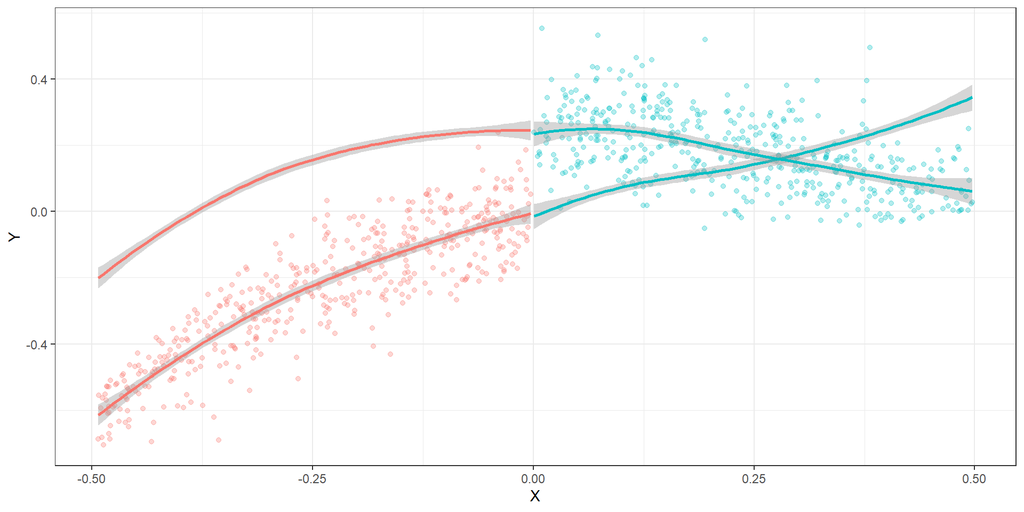

```r
rdd_design  |> draw_data() |> ggplot(aes(X, Y, color = factor(D))) +
  geom_point(alpha = .3) + theme_bw() +
  geom_smooth(aes(X, Y_D_0)) + geom_smooth(aes(X, Y_D_1)) + theme(legend.position = "none")
```

### 2.10 RDD diagnosis

```r
rdd_design |> diagnose_design()
```

| Estimator | Mean Estimate | Bias | SD Estimate | Coverage |
| --- | --- | --- | --- | --- |
| lm | 0.23 | -0.02 | 0.01 | 0.64 |
|  | (0.00) | (0.00) | (0.00) | (0.02) |
| optimal | 0.25 | 0.00 | 0.03 | 0.89 |
|  | (0.00) | (0.00) | (0.00) | (0.01) |

### 2.11 Bandwidth tradeoff

```r
rdd_design |>
  redesign(bandwidth = seq(from = 0.05, to = 0.5, by = 0.05)) |>
  diagnose_designs()
```

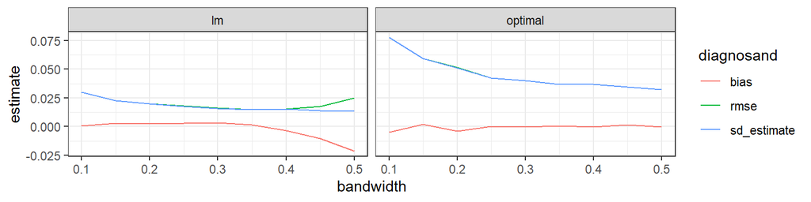

- As we increase the bandwidth, the lm bias gets worse, but slowly, while the error falls.
- The best bandwidth is relatively wide.
- This is more true for the optimal estimator.

### 2.12 Geographic RDs

Are popular in political science:

- Put a lot of pressure on assumption of no alternative treatment—including “random” country level shocks!
- Put a lot of pressure on no sorting assumptions (why was the border put where it was; why did units settle here or there?)
- Put a lot of pressure on SUTVA: people on one side are literally proximate to people on another

See Keele and Titiunik (2015)

## 3 Synthetic controls

Interested in the effect of an intervention on a single unit.

Available data: time series for unit of interest and possible comparison groups

### 3.1 Core idea

- Generate a Frankenstein control from weighting a set of control units so that they collectively track the unit of interest and can plausibly serve as a counterfactual.
- Identify weights $w$ that minimize $\left(Y_i^s(0) - \sum_{j\neq i} w_j Y_j^s(0)\right)^2$ in time period(s) $s$, prior to treatment; use these to predict counterfactual outcomes $Y^t_i(0)$ in later periods, $t$
- Note, in Abadie and Gardeazabal (2003) weights are chosen to minimize $(X_1 - X_0W)'V(X_1 - X_0W)$ where $X_1$, $X_0$ are covariates in the unit of interest and the “donor” units respectively. $V$ is chosen so that the pre treatment *outcomes* are as close as possible.

### 3.2 Optimization problem

In practice weights are found using a two stage minimization procedure:

1. Given matrix $V$ choose $W(V)$ to minimize $(X_1-X_0W)'V(X1-X_0W)$
2. Choose $V$ to minimize $(Z_1-Z_0W(V))'(X1-X_0W(V))$

So in effect you end up with weights on cases and also weights on variables

### 3.3 Basque example

- The seminal study is: Abadie and Gardeazabal (2003) which examines the impact of conflict on the Basque area
- A vignette showing how to use the [`SCtools`](https://cran.r-project.org/web/packages/SCtools/index.html) package to implement synthetic controls for this example is (here)[https://cran.r-project.org/web/packages/SCtools/vignettes/replicating-basque.html]
- We will walk through this and then interrogate this with a common package and a tidy version

### 3.4 Basque example

Packages and data:

```r
library(SCtools)
library(Synth)
data("basque")
```

### 3.5 Basque example

Some fairly nasty data manipulation:

```r
f_dataprep  <- function(data, time_plot = min(data$year):max(data$year))
  dataprep(
  foo = data,
  predictors = c("school.illit", "school.prim", "school.med",
     "school.high", "school.post.high",
    "invest"),
  predictors.op = "mean",
  time.predictors.prior = 1964:1969,
  special.predictors = list(
    list("gdpcap", 1960:1969 ,"mean"),
    list("sec.agriculture", seq(1961, 1969, 2), "mean"),
    list("sec.energy", seq(1961, 1969, 2), "mean"),
    list("sec.industry", seq(1961, 1969, 2), "mean"),
    list("sec.construction", seq(1961, 1969, 2), "mean"),
    list("sec.services.venta", seq(1961, 1969, 2), "mean"),
    list("sec.services.nonventa", seq(1961, 1969, 2), "mean"),
    list("popdens",               1969,               "mean")),
  dependent = "gdpcap",
  unit.variable = "regionno",
  unit.names.variable = "regionname",
  time.variable = "year",
  treatment.identifier = 17,
  controls.identifier = c(2:16, 18),
  time.optimize.ssr = 1960:1969,
  time.plot = time_plot)

dataprep.out  <- f_dataprep(basque)
```

### 3.6 Implementation (with messages)

```r
synth.out <- synth(data.prep.obj = dataprep.out, method = "BFGS")
```

```
X1, X0, Z1, Z0 all come directly from dataprep object.


****************
 searching for synthetic control unit


****************
****************
****************

MSPE (LOSS V): 0.008864606

solution.v:
 0.02773094 1.194e-07 1.60609e-05 0.0007163836 1.486e-07 0.002423908 0.0587055 0.2651997 0.02851006 0.291276 0.007994382 0.004053188 0.009398579 0.303975

solution.w:
 2.53e-08 4.63e-08 6.44e-08 2.81e-08 3.37e-08 4.844e-07 4.2e-08 4.69e-08 0.8508145 9.75e-08 3.2e-08 5.54e-08 0.1491843 4.86e-08 9.89e-08 1.162e-07
```

### 3.7 Results

This produces the following weights, selected to render the pre-treatment trends of the synthetic and actual controls as similar as possible.

| regionno | regionname | w.weight |
| --- | --- | --- |
| 1 | Spain (Espana) | NA |
| 2 | Andalucia | 0.00 |
| 3 | Aragon | 0.00 |
| 4 | Principado De Asturias | 0.00 |
| 5 | Baleares (Islas) | 0.00 |
| 6 | Canarias | 0.00 |
| 7 | Cantabria | 0.00 |
| 8 | Castilla Y Leon | 0.00 |
| 9 | Castilla-La Mancha | 0.00 |
| 10 | Cataluna | 0.85 |
| 11 | Comunidad Valenciana | 0.00 |
| 12 | Extremadura | 0.00 |
| 13 | Galicia | 0.00 |
| 14 | Madrid (Comunidad De) | 0.15 |
| 15 | Murcia (Region de) | 0.00 |
| 16 | Navarra (Comunidad Foral De) | 0.00 |
| 17 | Basque Country (Pais Vasco) | NA |
| 18 | Rioja (La) | 0.00 |

### 3.8 Plotting the counterfactual

Lets plot by hand and compare with package

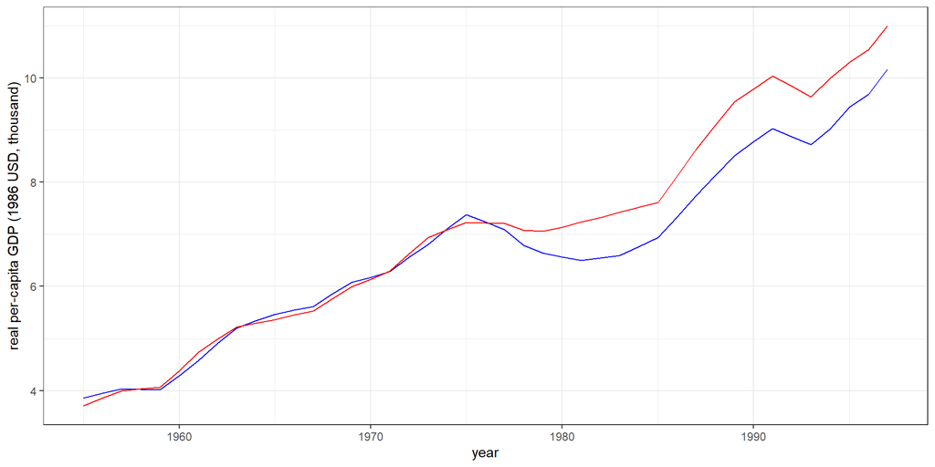

```r
basque_df <- basque |> filter(regionno == 17) |>
  mutate(counterfactual = .15*basque$gdpcap[basque$regionno == 14] + .85*basque$gdpcap[basque$regionno == 10] )

basque_df |> ggplot(aes(year, gdpcap)) + geom_line(color = "blue") +
  geom_line(aes(year, counterfactual), color = "red") + theme_bw() +
  ylab("real per-capita GDP (1986 USD, thousand)") + xlab("year")
```

### 3.9 Plotting 2

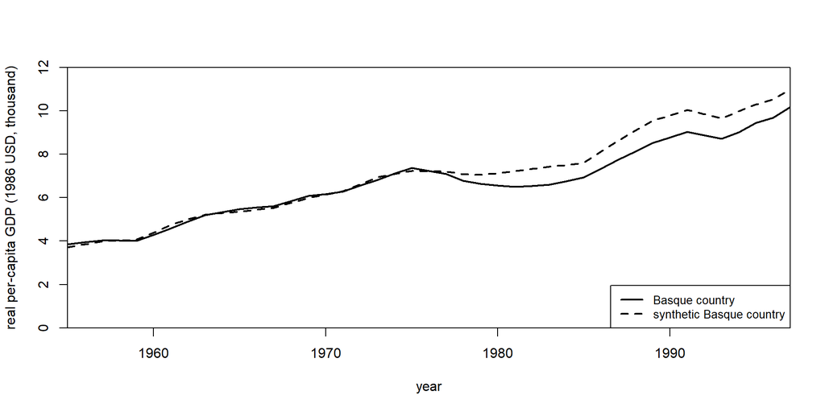

```r
path.plot(synth.res = synth.out, dataprep.res = dataprep.out,
          Ylab = "real per-capita GDP (1986 USD, thousand)", Xlab = "year",
          Ylim = c(0, 12), Legend = c("Basque country",
                                      "synthetic Basque country"),
          Legend.position = "bottomright")
```

### 3.10 Then what?

What is your estimate?

How do you do inference?

- Estimate could be at a particular point in time or averaging over a range. Inference often based on placebos: assess whether estimated effects are large relative to what you would get if you looked for effects in random places.
- This has an RI flavor to it, but we are not exploiting any actual randomization.
- Alternatives are to do sensitivity analyses, bootstrap (though this is really capturing sampling variability), and perhaps using estimates of the uncertainty from errors in pre treatment predictions.

### 3.11 `tidysynth` implementation

`tidysynth` a wrapper for `synth` and tidier for sure

Vignette on: Impact of Proposition 99 on cigarette consumption in California. https://github.com/edunford/tidysynth

```r
data("smoking")
smoking |> head() |> kable()
```

| state | year | cigsale | lnincome | beer | age15to24 | retprice |
| --- | --- | --- | --- | --- | --- | --- |
| Rhode Island | 1970 | 123.9 | NA | NA | 0.1831579 | 39.3 |
| Tennessee | 1970 | 99.8 | NA | NA | 0.1780438 | 39.9 |
| Indiana | 1970 | 134.6 | NA | NA | 0.1765159 | 30.6 |
| Nevada | 1970 | 189.5 | NA | NA | 0.1615542 | 38.9 |
| Louisiana | 1970 | 115.9 | NA | NA | 0.1851852 | 34.3 |
| Oklahoma | 1970 | 108.4 | NA | NA | 0.1754592 | 38.4 |

### 3.12 `tidysynth` implementation

In a pipe:

```r
smoking_out <-

  smoking %>%

  # initial the synthetic control object
  synthetic_control(
    outcome = cigsale, # outcome
    unit = state, # unit index in the panel data
    time = year, # time index in the panel data
    i_unit = "California", # unit where the intervention occurred
    i_time = 1988, # time period when the intervention occurred
    generate_placebos=T # generate placebo synthetic controls (for inference)
    )
```

### 3.13 add predictor information

```r
smoking_out <- smoking_out %>%

  # Generate the aggregate predictors used to fit the weights

  # average log income, retail price of cigarettes, and proportion of the
  # population between 15 and 24 years of age from 1980 - 1988
  generate_predictor(time_window = 1980:1988,
                     ln_income = mean(lnincome, na.rm = T),
                     ret_price = mean(retprice, na.rm = T),
                     youth = mean(age15to24, na.rm = T)) %>%

  # average beer consumption in the donor pool from 1984 - 1988
  generate_predictor(time_window = 1984:1988,
                     beer_sales = mean(beer, na.rm = T)) %>%

  # Lagged cigarette sales
  generate_predictor(time_window = 1975, cigsale_1975 = cigsale) %>%
  generate_predictor(time_window = 1980, cigsale_1980 = cigsale) %>%
  generate_predictor(time_window = 1988, cigsale_1988 = cigsale)
```

### 3.14 implement

```r
smoking_out <- smoking_out %>%


  # Generate the fitted weights for the synthetic control
  generate_weights(optimization_window = 1970:1988, # time for optimization
                   margin_ipop = .02,sigf_ipop = 7,bound_ipop = 6 # options
  ) %>%

  # Generate the synthetic control
  generate_control()
```

### 3.15 plot trends

```r
smoking_out %>% plot_trends()
```

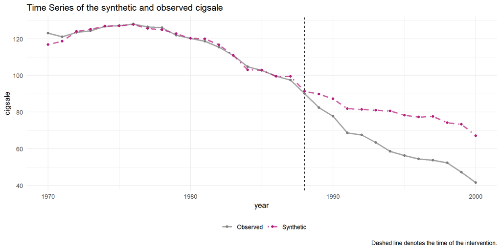

### 3.16 plot weights

```r
smoking_out %>% plot_weights()
```

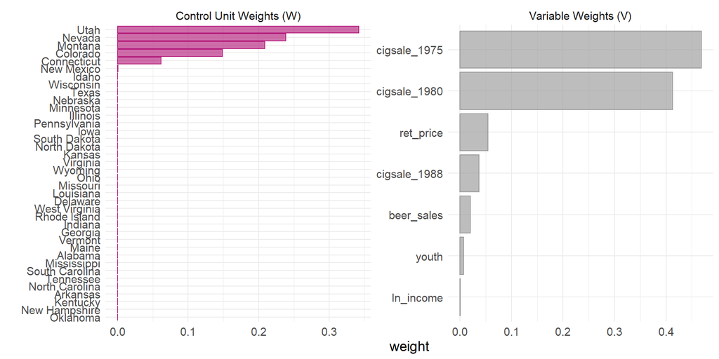

### 3.17 plot placebos

```r
smoking_out %>% plot_placebos()
```

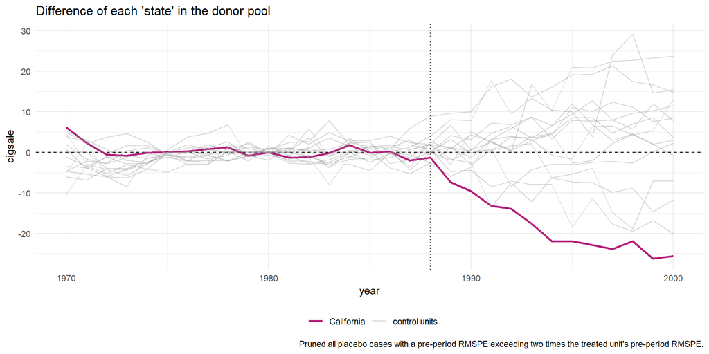

### 3.18 Design declaration

```r
sc_helper <- function(data, treatment_time = 2010)

  data |>

  # initial the synthetic control object
  synthetic_control(
    outcome = Y, # outcome
    unit = state, # unit index in the panel data
    time = year, # time index in the panel data
    i_unit = "01", # unit where the intervention occurred
    i_time = treatment_time, # time period when the intervention occurred
    generate_placebos = F  # generate placebo synthetic controls
    )  |>

  generate_predictor(time_window = 2000:2020,
                     lnincome = mean(ln_income, na.rm = T),
                     youth = mean(age15to24, na.rm = T)) %>%
  generate_weights(optimization_window = 2000:2010, # time for optimization
                   margin_ipop = .02,sigf_ipop = 7,bound_ipop = 6 # options
  ) |>
  generate_control()
```

### 3.19 Declare an estimator

```r
sc_estimator <- function(data, treatment_time = 2010)

  data.frame(estimate =
               sc_helper(data, treatment_time = 2010) |>
               grab_synthetic_control() |>
               mutate(difference = real_y - synth_y) |>
               filter(time_unit >= treatment_time) |>
               pull(difference) |>
               mean()
)
```

### 3.20 Design

```r
design <-
  declare_model(
    state = add_level(50,
                      youth_mean = runif(N, .2, .7),
                      income_mean = runif(N, 1, 5),
                      b = runif(N, 0, 10)),
    time = add_level(21, year = 2000:2020, nest = FALSE),
    unit = cross_levels(join_using(state, time))) +

  declare_model(
    treatment = 1*(state == "01" & (year >=2010)),
    age15to24 = youth_mean + .5*runif(N, -.1, .1) - .2*(year- 2000),
    ln_income = income_mean + .5*rlnorm(N),
    Y = 5*age15to24 + .1*(year- 2000)^2 +  1*ln_income + b* treatment) +

  declare_inquiry(b[1]) +

  declare_estimator(handler = label_estimator(sc_estimator))
```

### 3.21 Inspection

```r
draw_data(design) |> sc_helper()  |> plot_trends()
```

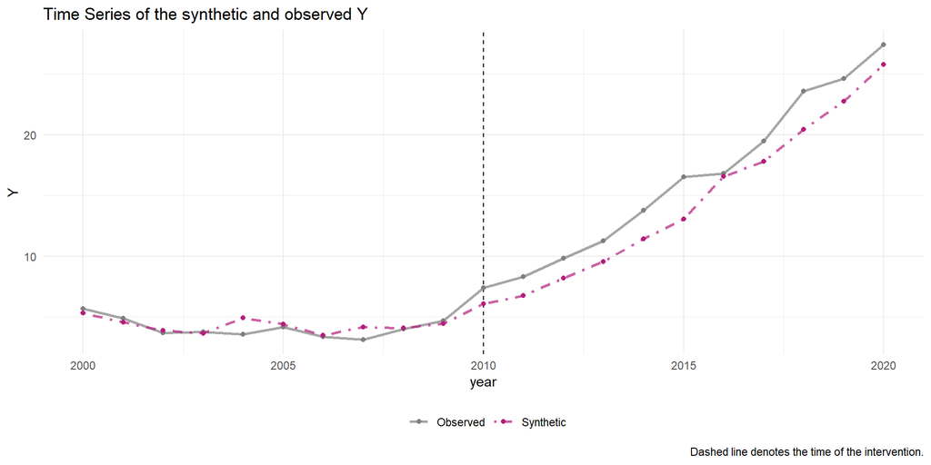

### 3.22 Simulation

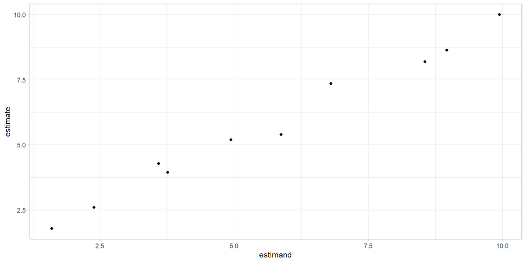

```r
simulations <- simulate_design(design, sims = 10)

simulations |> ggplot(aes(estimand, estimate)) + geom_point()
```

Abadie, Alberto, and Javier Gardeazabal. 2003. “The Economic Costs of Conflict: A Case Study of the Basque Country.” *American Economic Review* 93 (1): 113–32.

Calonico, Sebastian, Matias D Cattaneo, and Rocio Titiunik. 2014. “Robust Nonparametric Confidence Intervals for Regression-Discontinuity Designs.” *Econometrica* 82 (6): 2295–2326.

Keele, Luke J, and Rocio Titiunik. 2015. “Geographic Boundaries as Regression Discontinuities.” *Political Analysis* 23 (1): 127–55.

Lee, David S, and Thomas Lemieux. 2010. “Regression Discontinuity Designs in Economics.” *Journal of Economic Literature* 48 (2): 281–355.